# DS 202 Lab 4

Michael Egle ; John Chandara mrpotatofactory@gmail.com

3/19/2020

```r
library(readxl)
library(tidyverse)
```

```r
defense <- read_excel('cyclonesFootball2019.xlsx', sheet='Defensive')
offense <- read_excel('cyclonesFootball2019.xlsx', sheet='Offensive')
bio <- read_excel('cyclonesFootball2019.xlsx', sheet='Biography')
```

Data cleaning for offense

```r
offense <- offense %>%
  mutate_at(.vars = vars(Name, Opponent_Opponent),
            .funs = funs(as.factor))
offense <- offense %>%
  separate('Passing_CMP-ATT', into = c('Passing_CMP', 'Passing_ATT'), sep = '-\r\n')

offense <- offense %>%
  mutate_at(.vars = vars(Rushing_ATT, Rushing_YDS, Rushing_TD, Receiving_REC,
                         Receiving_YDS, Receiving_TD, Passing_CMP, Passing_ATT,
                         Passing_YDS, Passing_TD, Passing_INT),
            .funs = funs(as.numeric))
```

```r
str(offense)
```

```
## Classes 'tbl_df', 'tbl' and 'data.frame':    195 obs. of  13 variables:
##  $ Name             : Factor w/ 17 levels "Akers, Landen",..: 1 1 1 1 1 1 1 1 1 1 ...
##  $ Opponent_Opponent: Factor w/ 13 levels "Baylor","Iowa",..: 12 2 11 1 8 13 10 7 6 9 ...
##  $ Rushing_ATT      : num  0 0 1 0 0 0 0 0 0 0 ...
##  $ Rushing_YDS      : num  0 0 8 0 0 0 0 0 0 0 ...
##  $ Rushing_TD       : num  0 0 0 0 0 0 0 0 0 0 ...
##  $ Receiving_REC    : num  1 0 0 0 1 0 0 4 0 1 ...
##  $ Receiving_YDS    : num  21 0 0 0 32 0 0 39 0 7 ...
##  $ Receiving_TD     : num  0 0 0 0 0 0 0 0 0 0 ...
##  $ Passing_CMP      : num  NA NA NA NA NA NA NA NA NA NA ...
##  $ Passing_ATT      : num  NA NA NA NA NA NA NA NA NA NA ...
##  $ Passing_YDS      : num  NA NA NA NA NA NA NA NA NA NA ...
##  $ Passing_TD       : num  NA NA NA NA NA NA NA NA NA NA ...
##  $ Passing_INT      : num  NA NA NA NA NA NA NA NA NA NA ...
```

Data cleaning for defense

```r
defense <- defense %>%
  mutate_at(.vars = vars(Name, Opponent_Opponent),
            .funs = funs(as.factor))

defense <- defense %>%
  mutate_at(.vars = vars(Tackles_Solo, Tackles_ASST, Tackles_TFL,
                         Tackles_Sack, Turnover_FF, Turnover_FR,
                         Turnover_INT, Pass_QBH, Pass_PB),
            .funs = funs(as.numeric))
```

```r
str(defense)
```

```
## Classes 'tbl_df', 'tbl' and 'data.frame':    502 obs. of  11 variables:
##  $ Name             : Factor w/ 43 levels "Akers, Landen",..: 40 40 40 40 40 40 40 40 40 40 ...
##  $ Opponent_Opponent: Factor w/ 13 levels "Baylor","Iowa",..: 12 2 11 1 8 13 10 7 6 9 ...
##  $ Tackles_Solo     : num  4 4 3 4 3 1 7 3 6 5 ...
##  $ Tackles_ASST     : num  4 7 5 2 2 1 1 2 1 5 ...
##  $ Tackles_TFL      : num  0 0 0 0 1 0 0 0 1 1 ...
##  $ Tackles_Sack     : num  0 0 0 0 0 0 0 0 0 1 ...
##  $ Turnover_FF      : num  0 0 0 0 0 0 0 0 0 0 ...
##  $ Turnover_FR      : num  0 0 0 0 0 0 0 0 0 0 ...
##  $ Turnover_INT     : num  0 0 1 0 0 0 0 0 1 0 ...
##  $ Pass_QBH         : num  1 0 0 0 0 0 0 0 1 0 ...
##  $ Pass_PB          : num  1 2 0 0 0 1 0 0 0 0 ...
```

Data cleaning for biographies

```r
bio <- bio %>%
  mutate_at(.vars = vars(Name, Position),
            .funs = funs(as.factor))

bio <- bio %>%
  separate('Height', into = c('Height_Ft', 'Height_In'), sep = "-")

bio <- bio %>%
  mutate_at(.vars = vars(Weight, Height_Ft, Height_In),
            .funs = funs(as.numeric))

bio <- bio %>%
  mutate(Height = 12 * Height_Ft + Height_In)
```

```r
str(bio)
```

```
## Classes 'tbl_df', 'tbl' and 'data.frame':    105 obs. of  9 variables:
##  $ Name      : Factor w/ 105 levels "Akers, Landen",..: 1 2 3 4 5 6 7 8 9 10 ...
##  $ Position  : Factor w/ 14 levels "Deep Snapper",..: 14 13 14 9 2 3 3 4 4 11 ...
##  $ Height_Ft : num  6 6 6 6 6 6 6 6 6 6 ...
##  $ Height_In : num  0 7 5 0 0 3 2 2 0 6 ...
##  $ Weight    : num  188 245 204 195 190 235 255 285 300 215 ...
##  $ Class     : chr  "Redshirt Senior" "Redshirt Senior" "Redshirt Freshman" "Redshirt Senior" ...
##  $ Hometown  : chr  "Cedar Rapids, Iowa" "Nixa, Mo." "Seffner, Fla." "Naperville, Ill." ...
##  $ Highschool: chr  "Washington" "Nixa" "Armwood" "Central" ...
##  $ Height    : num  72 79 77 72 72 75 74 74 72 78 ...
```

Now that all the variables are of the desired type we can reassign the dataframes

```r
offclean <- offense
defclean <- defense
bioclean <- bio
```

1. Reformat the defClean data frame into a tidy format using pivot_longer. The type of statistic (Tackles_Solo, Tackles_ASST, etc) is added as a new key column named Statistic.

```r
defclean <- defclean %>%
  pivot_longer(Tackles_Solo:Pass_PB,
               names_to = "Statistic",
               values_to = "Count")
```

2. Create a histogram for each defensive statistic. Use facet_wrap to draw all histograms in a single plot. What defensive skills are rare?

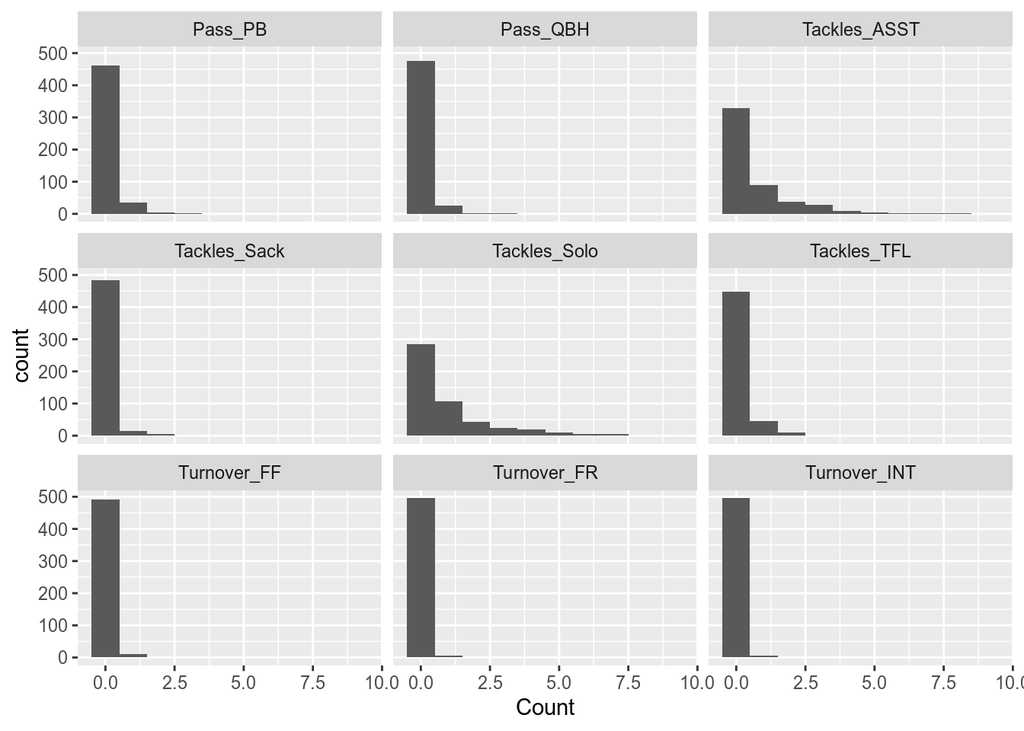

```r
defclean %>%
  ggplot(aes(x = Count)) +
  geom_histogram(binwidth = 1) +
  facet_wrap(. ~ Statistic)
```

The most rare defensive statistics to accumulate are turnovers (forced fumble, fumble recoveries, and interceptions) which isn’t a big shock. Turnovers in football have an element of luck to them as they can sometimes rely on error on the offense’s part. As a result, turnovers can be a “right place, right time” thing.

3. Did ISU have better defense against West Virginia or Kansas State? Answer this question by creating a scatterplot with x-axis being the number of solo tackles (by each player) against West Virginia, and y-axis being that against Kansas State. A large number of solo tackles indicates good defense.

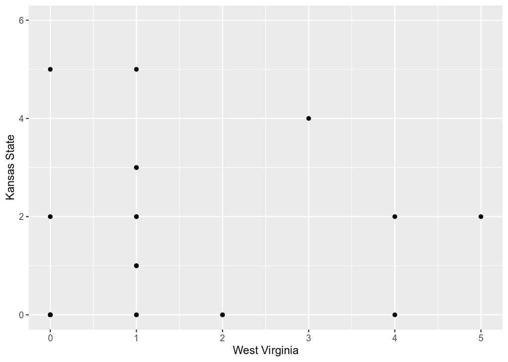

```r
defclean %>%
  pivot_wider(names_from = Opponent_Opponent, values_from = Count) %>%
  filter(Statistic == "Tackles_Solo") %>%
  ggplot(aes(x = `West Virginia`, y = `Kansas State`)) +
  geom_point()
```

A lot more players had zero solo tackles against Kansas State than they did against West Virginia. Nine players recorded at least one solo tackle against Kansas State, whereas ten recorded at least one against West Virginia. I would say overall the defense performed better against West Virginia.

4. Separate the Hometown column into two columns, namely the city and the state. Print the first few rows of these two columns. (Hint: look at the sep= argument of separate)

```r
bioclean <- bioclean %>%
  separate(Hometown, into = c("Home_town", "Home_state"), sep = ", ")
```

5. How many players are there from each state?

```r
bioclean %>%
  group_by(Home_state) %>%
  summarize(count = n()) %>%
  arrange(desc(count)) %>%
  head()
```

```
## # A tibble: 6 x 2
##   Home_state count
##   <chr>      <int>
## 1 Iowa          35
## 2 Fla.          10
## 3 Ohio           7
## 4 Mo.            6
## 5 Texas          6
## 6 Wis.           6
```

Most players on Iowa State’s football roster are from Iowa, Florida, Ohio, Missouri, Texas, or Wisconsin.

6. Find where do the offensive players come from by joining the offensive data and player biography data appropriately.

```r
offenseBio <- full_join(offclean, bio, by = 'Name')
```

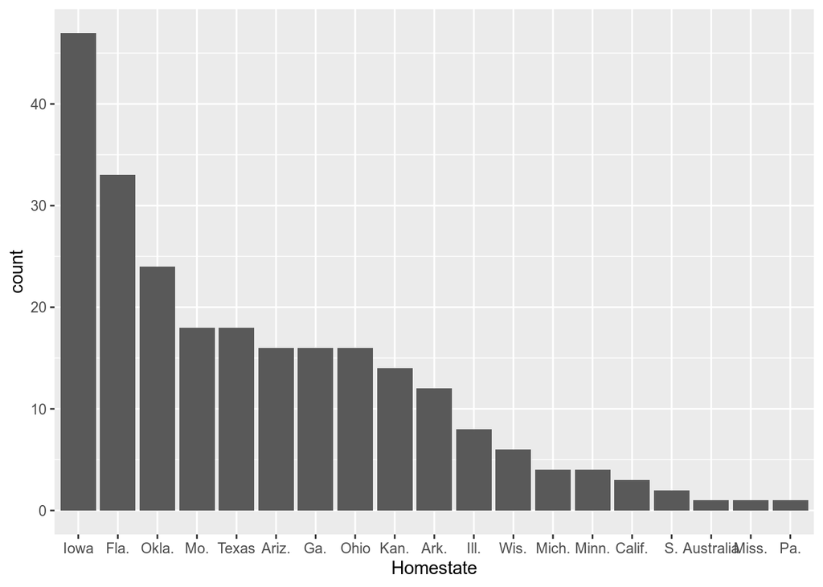

```r
offenseBio <- offenseBio[!is.na(offenseBio$Hometown), ]
offenseBio$Homestate <- str_match(offenseBio$Hometown, '[A-z ]+, (\\w+.?)')[,2]

table <- table(offenseBio$Homestate)
offenseBio$Homestate <- factor(offenseBio$Homestate, levels = names(table)[order(table, decreasing = TRUE)])

offenseBio %>%
  ggplot(aes(x = Homestate)) + geom_bar()
```

Most of the offenseive players originate from Iowa, Florda or, Oklahoma.

7. Is there a relationship between the weight of a player and the receiving yards (Receiving_YDS)?

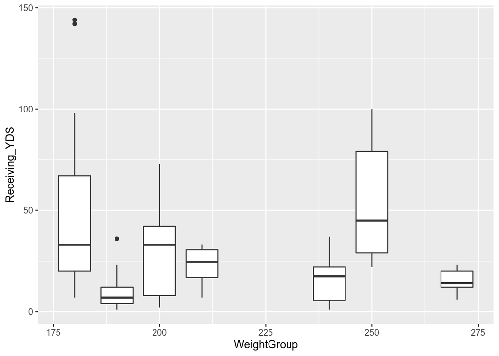

```r
offenseBioRecCull <- offenseBio %>%
      filter(Receiving_YDS != 0 & !is.na(Receiving_YDS))

offenseBioRecCull$Receiving_YDS <- as.numeric(offenseBioRecCull$Receiving_YDS)
offenseBioRecCull$IntWeight <- as.numeric(offenseBioRecCull$Weight)
offenseBioRecCull$WeightGroup <- floor(offenseBioRecCull$IntWeight / 10) * 10
offenseBioRecCull %>%
  ggplot(aes(x = WeightGroup, y = Receiving_YDS, group = WeightGroup)) +
    geom_boxplot()
```

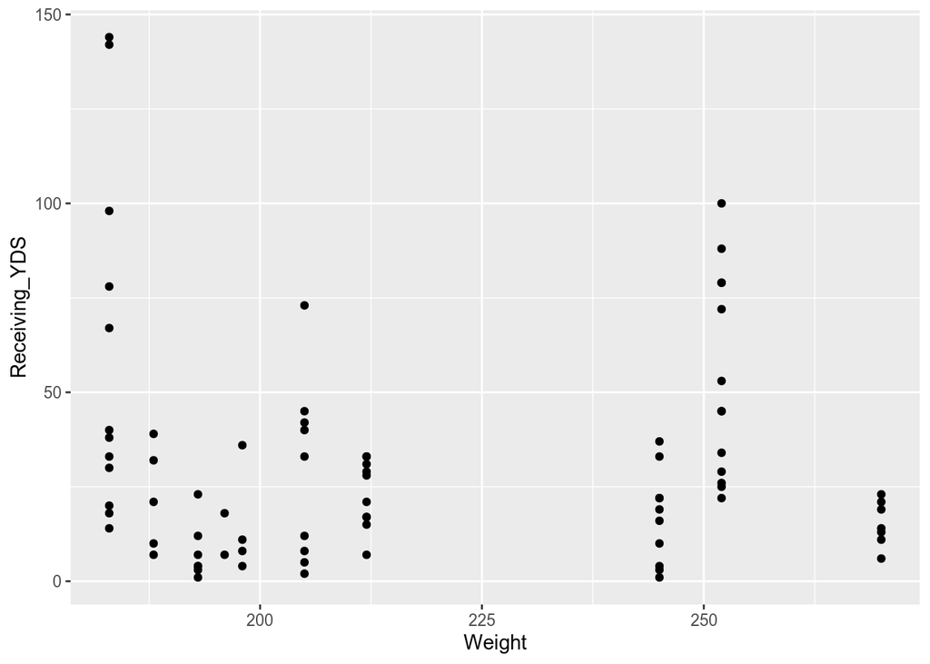

```r
offenseBioRecCull %>%
  ggplot(aes(x = Weight, y = Receiving_YDS)) +
    geom_point()
```

There does not appear to be any relationship between these variables, aside from major outliers for those who weigh 183 lbs.

8. How does the performance of quarterback Brock Purdy relate to the performance of the ISU team?

```r
offPurdy <- offclean

purdyCull <- offclean$Name == "Purdy, Brock"
offenseNoPurdyCull <- offense[!purdyCull, ]
offensePurdyCull <- offense[purdyCull, ]
purdySummary <- offensePurdyCull %>%
  group_by(Opponent_Opponent) %>%
    summarize(
      Rushing_ATT = mean(Rushing_ATT, na.rm = TRUE),
      Rushing_YDS = mean(Rushing_YDS, na.rm = TRUE),
      Rushing_TD  = mean(Rushing_TD,  na.rm = TRUE),
      Receiving_REC = mean(Receiving_REC,  na.rm = TRUE),
      Receiving_YDS = mean(Receiving_YDS,  na.rm = TRUE),
      Receiving_TD = mean(Receiving_TD,  na.rm = TRUE),
      Passing_CMP = mean(Passing_CMP,  na.rm = TRUE),
      Passing_ATT = mean(Passing_ATT,  na.rm = TRUE),
      Passing_YDS = mean(Passing_YDS,  na.rm = TRUE),
      Passing_TD = mean(Passing_TD,  na.rm = TRUE),
      Passing_INT  = mean(Passing_INT,  na.rm = TRUE),
    )

noPurdySummary <- offenseNoPurdyCull %>%
  group_by(Opponent_Opponent) %>%
    summarize(
      Rushing_ATT = mean(Rushing_ATT, na.rm = TRUE),
      Rushing_YDS = mean(Rushing_YDS, na.rm = TRUE),
      Rushing_TD  = mean(Rushing_TD,  na.rm = TRUE),
      Receiving_REC = mean(Receiving_REC,  na.rm = TRUE),
      Receiving_YDS = mean(Receiving_YDS,  na.rm = TRUE),
      Receiving_TD = mean(Receiving_TD,  na.rm = TRUE),
      Passing_CMP = mean(Passing_CMP,  na.rm = TRUE),
      Passing_ATT = mean(Passing_ATT,  na.rm = TRUE),
      Passing_YDS = mean(Passing_YDS,  na.rm = TRUE),
      Passing_TD = mean(Passing_TD,  na.rm = TRUE),
      Passing_INT  = mean(Passing_INT,  na.rm = TRUE),
    )

purdySummary$Who = 'Purdy'
noPurdySummary$Who = 'ISU Team'
Summary <- full_join(purdySummary, noPurdySummary)
```

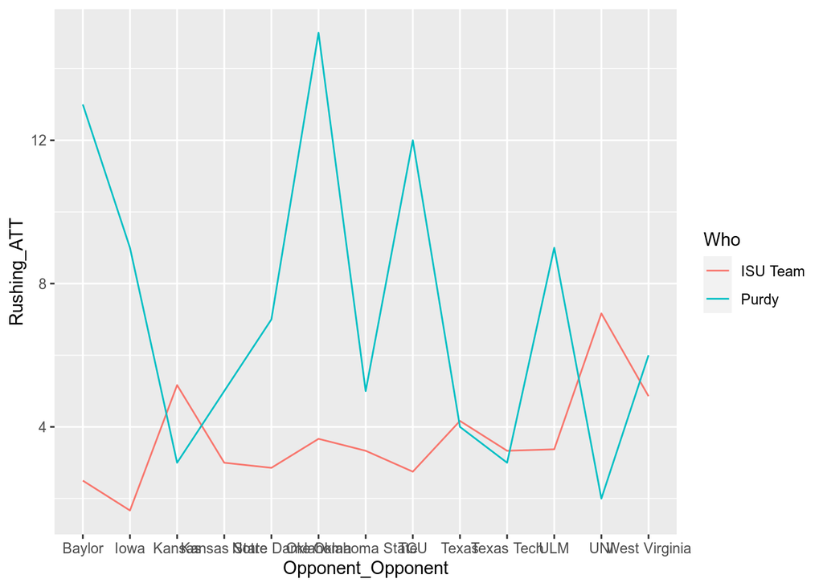

```r
Summary %>%
  ggplot(aes(y = Rushing_ATT, x = Opponent_Opponent, group = Who, col = Who)) + geom_line()
```

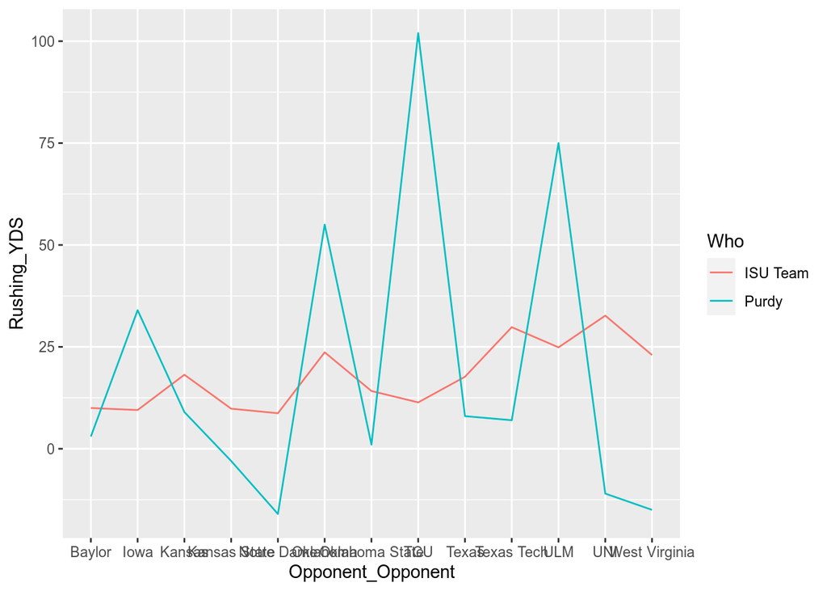

```r
Summary %>%
  ggplot(aes(y = Rushing_YDS, x = Opponent_Opponent, group = Who, col = Who)) + geom_line()
```

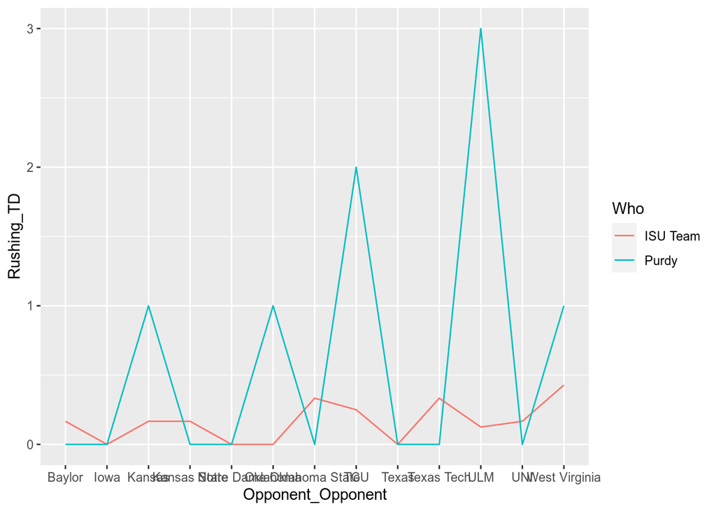

```r
Summary %>%
  ggplot(aes(y = Rushing_TD, x = Opponent_Opponent, group = Who, col = Who)) + geom_line()
```

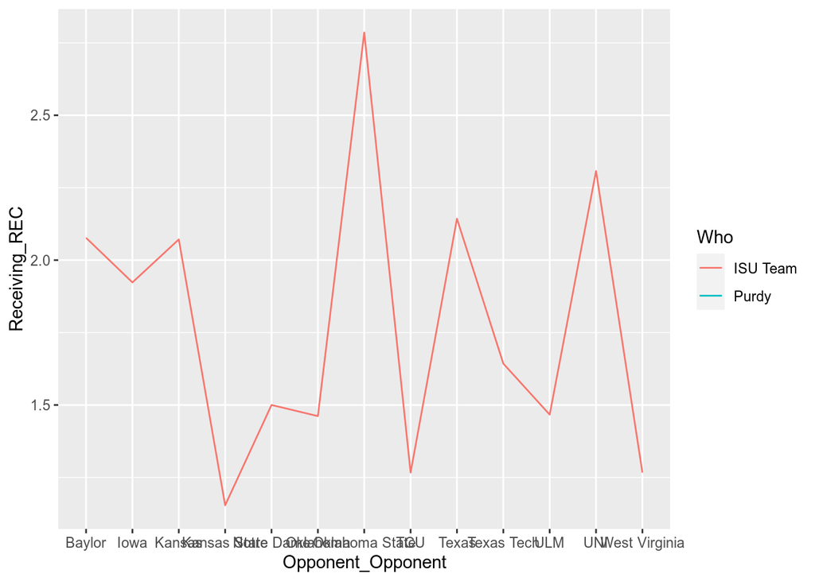

```r
Summary %>%
  ggplot(aes(y = Receiving_REC, x = Opponent_Opponent, group = Who, col = Who)) + geom_line()
```

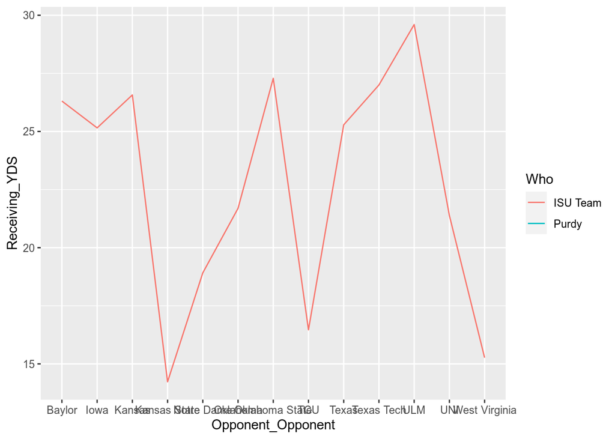

```r
Summary %>%
  ggplot(aes(y = Receiving_YDS, x = Opponent_Opponent, group = Who, col = Who)) + geom_line()
```

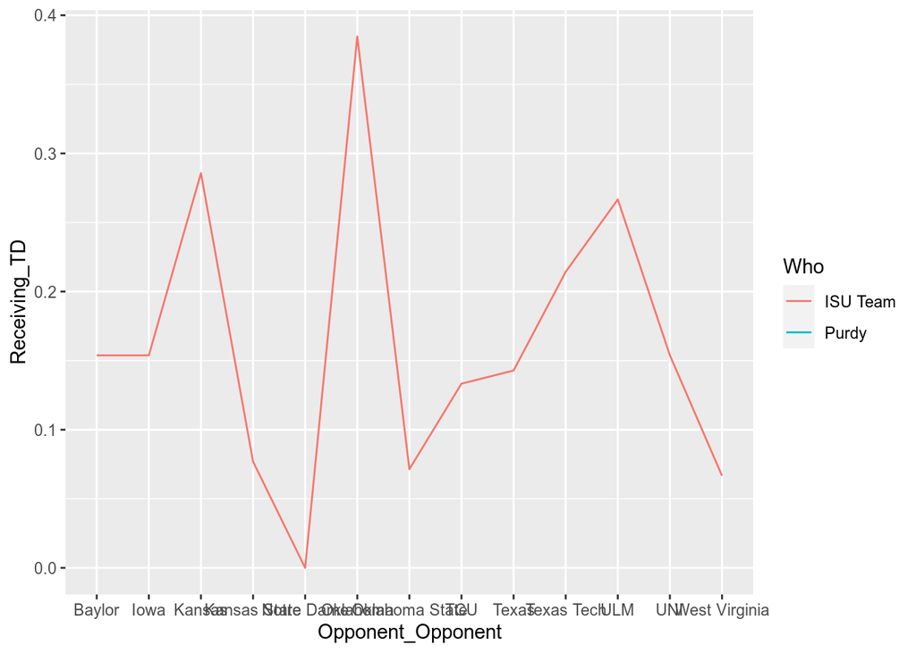

```r
Summary %>%
  ggplot(aes(y = Receiving_TD, x = Opponent_Opponent, group = Who, col = Who)) + geom_line()
```

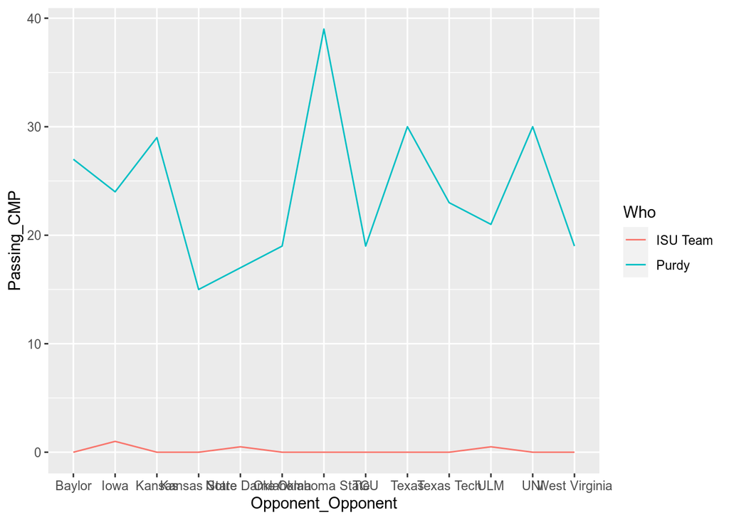

```r
Summary %>%
  ggplot(aes(y = Passing_CMP, x = Opponent_Opponent, group = Who, col = Who)) + geom_line()
```

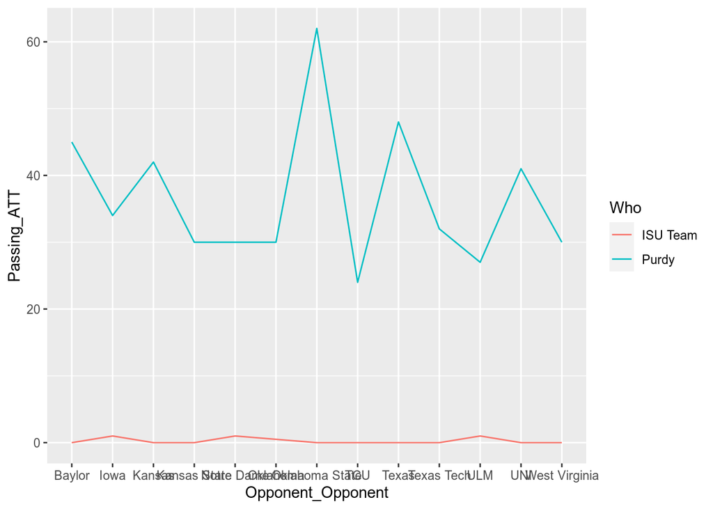

```r
Summary %>%
  ggplot(aes(y = Passing_ATT, x = Opponent_Opponent, group = Who, col = Who)) + geom_line()
```

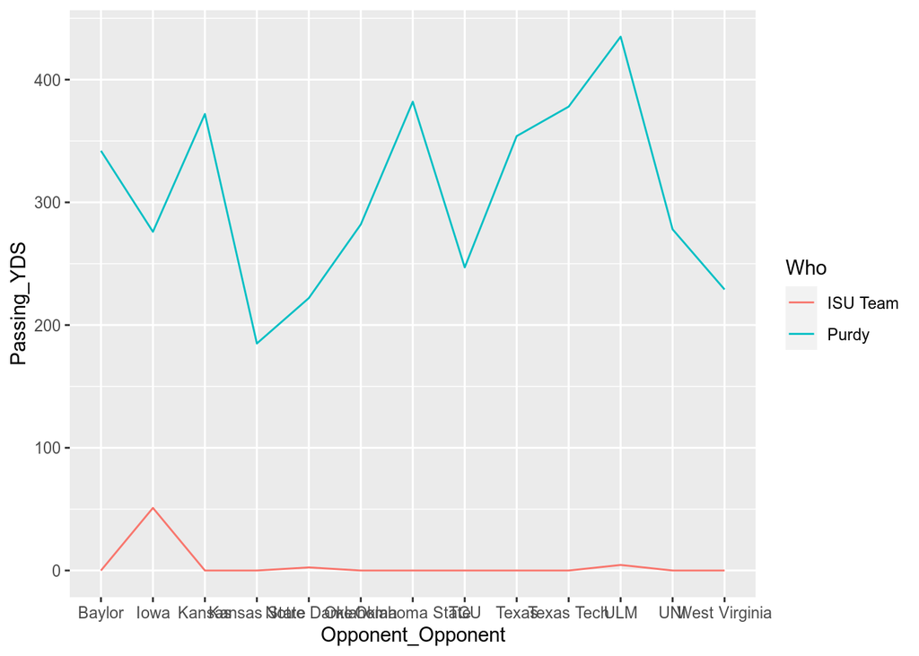

```r
Summary %>%
  ggplot(aes(y = Passing_YDS, x = Opponent_Opponent, group = Who, col = Who)) + geom_line()
```